# STAT 9250 - Homework 1

Your Name

2026-02-16

## Problem 1

```r
N_grid <- c(200, 400, 600, 800, 1000, 1200, 1500)
B_reps <- 3

results <- data.frame(
  N = N_grid,
  time_direct = NA,
  time_smw = NA,
  flops_direct = flops_direct(N_grid),
  flops_smw = flops_smw(N_grid, M),
  rel_error = NA
)

for (i in seq_along(N_grid)) {

  N <- N_grid[i]
  cat("Running N =", N, "\n")

  K <- matrix(rnorm(N*M), nrow = N)

  # ---- Direct timing ----
  t1 <- replicate(B_reps, {
    system.time(inv_direct(K, sigma))["elapsed"]
  })
  results$time_direct[i] <- median(t1)

  # ---- SMW timing ----
  t2 <- replicate(B_reps, {
    system.time(inv_smw(K, sigma))["elapsed"]
  })
  results$time_smw[i] <- median(t2)

  # ---- Accuracy check ----
  A1 <- inv_direct(K, sigma)
  A2 <- inv_smw(K, sigma)

  results$rel_error[i] <-
    norm(A1 - A2, "F") / norm(A1, "F")
}
```

```
## Running N = 200
## Running N = 400
## Running N = 600
## Running N = 800
## Running N = 1000
## Running N = 1200
## Running N = 1500
```

```r
results
```

| N | time_direct | time_smw | flops_direct | flops_smw | rel_error |
| --- | --- | --- | --- | --- | --- |
| 200 | 0.01 | 0.00 | 2666667 | 880333.3 | 3.851287e-14 |
| 400 | 0.04 | 0.00 | 21333333 | 3360333.3 | 5.599104e-14 |
| 600 | 0.12 | 0.00 | 72000000 | 7440333.3 | 7.086293e-14 |
| 800 | 0.28 | 0.00 | 170666667 | 13120333.3 | 8.149068e-14 |
| 1000 | 0.56 | 0.01 | 333333333 | 20400333.3 | 8.688306e-14 |
| 1200 | 0.96 | 0.01 | 576000000 | 29280333.3 | 1.001302e-13 |
| 1500 | 1.96 | 0.02 | 1125000000 | 45600333.3 | 1.106781e-13 |

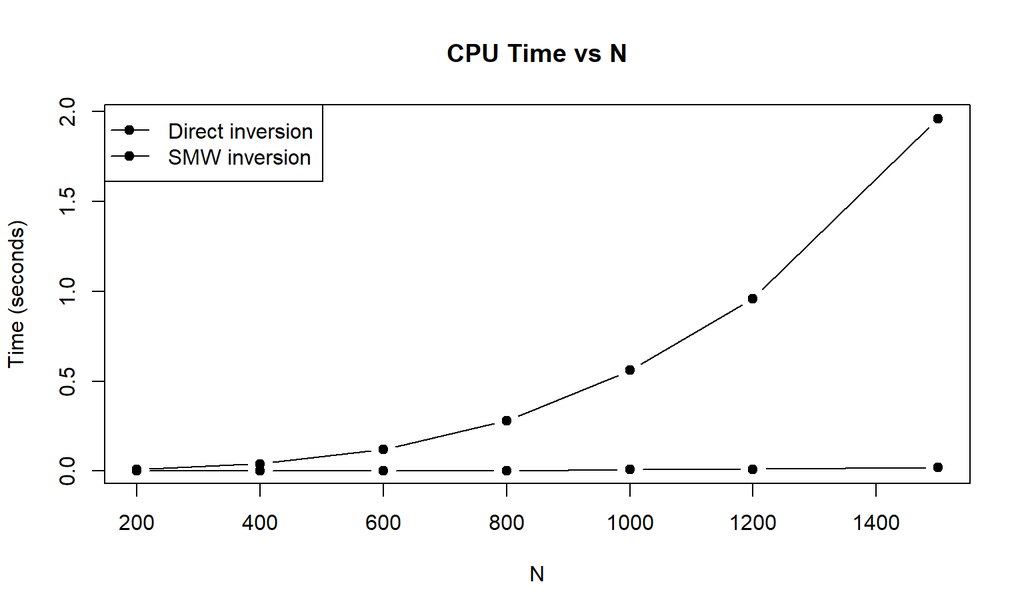

```r
plot(results$N, results$time_direct,
     type="b", pch=19,
     xlab="N",
     ylab="Time (seconds)",
     main="CPU Time vs N")
lines(results$N, results$time_smw,
      type="b", pch=19)
legend("topleft",
       legend=c("Direct inversion",
                "SMW inversion"),
       lty=1, pch=19)
```

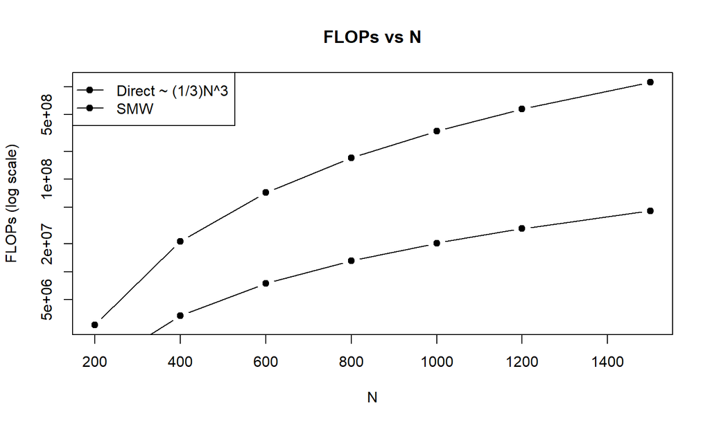

```r
plot(results$N,
     results$flops_direct,
     type="b", pch=19,
     log="y",
     xlab="N",
     ylab="FLOPs (log scale)",
     main="FLOPs vs N")
lines(results$N,
      results$flops_smw,
      type="b", pch=19)
legend("topleft",
       legend=c("Direct ~ (1/3)N^3",
                "SMW"),
       lty=1, pch=19)
```

The computational results clearly show a dramatic difference in growth rates between the two methods.

This confirms that exploiting the low-rank structure of $KK^T$ provides substantial computational savings when $M \ll N$.

## Problem 2

```r
# CHANGE THIS PATH to where Temp_data.RData lives
load("Temp_data.RData")

# Try to detect object names robustly
obj_names <- ls()
obj_names
```

```
##  [1] "A1"           "A2"           "B_reps"       "flops_direct" "flops_smw"
##  [6] "i"            "inv_direct"   "inv_smw"      "K"            "M"
## [11] "N"            "N_grid"       "results"      "sigma"        "stations"
## [16] "t1"           "t2"           "Temp_UB"      "Xmat"
```

```r
# Assume these names (adjust if your .RData uses different ones)
y <- get(if ("Temp_UB" %in% obj_names) "Temp_UB" else if ("TempUB" %in% obj_names) "TempUB" else "y")
Xmat <- get(if ("Xmat" %in% obj_names) "Xmat" else "Xmat")
stations <- get(if ("stations" %in% obj_names) "stations" else "stations")

n <- nrow(Xmat); p <- ncol(Xmat)
cat("n =", n, "p =", p, "\n")
```

```
## n = 37511 p = 3535
```

```r
summary(y)
```

```
##    Min. 1st Qu.  Median    Mean 3rd Qu.    Max.
##   3.416  30.229  33.748  33.378  36.808  57.665
```

```r
str(stations)
```

```
## 'data.frame':    37511 obs. of  2 variables:
##  $ lon: num  55.52 3.25 2.87 9.63 5.43 ...
##  $ lat: num  25.3 36.7 30.6 28.1 22.8 ...
```

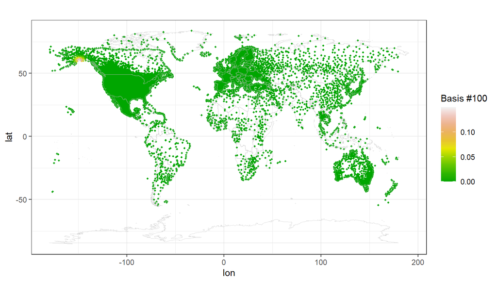

```r
plot_basis <- function(basis_num, cap = 0.15) {
  ggplot(stations) +
    geom_point(aes(x = lon, y = lat, col = Xmat[, basis_num]), size = 0.7) +
    geom_path(
      data = map_data("world"),
      aes(x = long, y = lat, group = group),
      color = "gray", linewidth = 0.2, alpha = 0.5
    ) +
    scale_color_gradientn(
      colours = terrain.colors(10),
      name = paste0("Basis #", basis_num),
      na.value = "transparent",
      limits = c(0, cap)
    ) +
    coord_fixed(1.3) +
    theme_bw() +
    labs(x = "lon", y = "lat")
}

b1 <- 100
b2 <- 2000

plot_basis(b1)
```

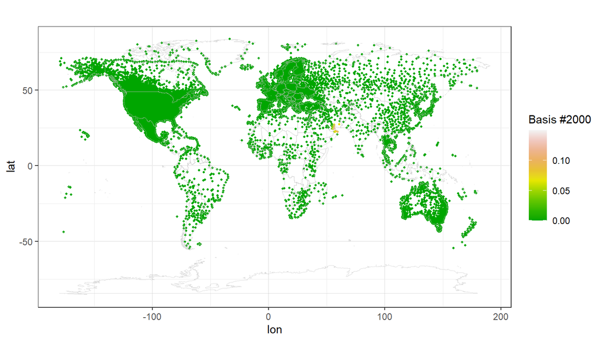

```r
plot_basis(b2)
```

```r
XtX <- crossprod(Xmat)  # t(X)%*%X
dim(XtX)
```

```
## [1] 3535 3535
```

```r
res_try <- tryCatch(
  {
    solve(XtX)
    "solve(XtX) succeeded (no error)."
  },
  error = function(e) paste("ERROR:", e$message),
  warning = function(w) paste("WARNING:", w$message)
)
res_try
```

```
## [1] "ERROR: Lapack routine dgesv: system is exactly singular: U[1362,1362] = 0"
```

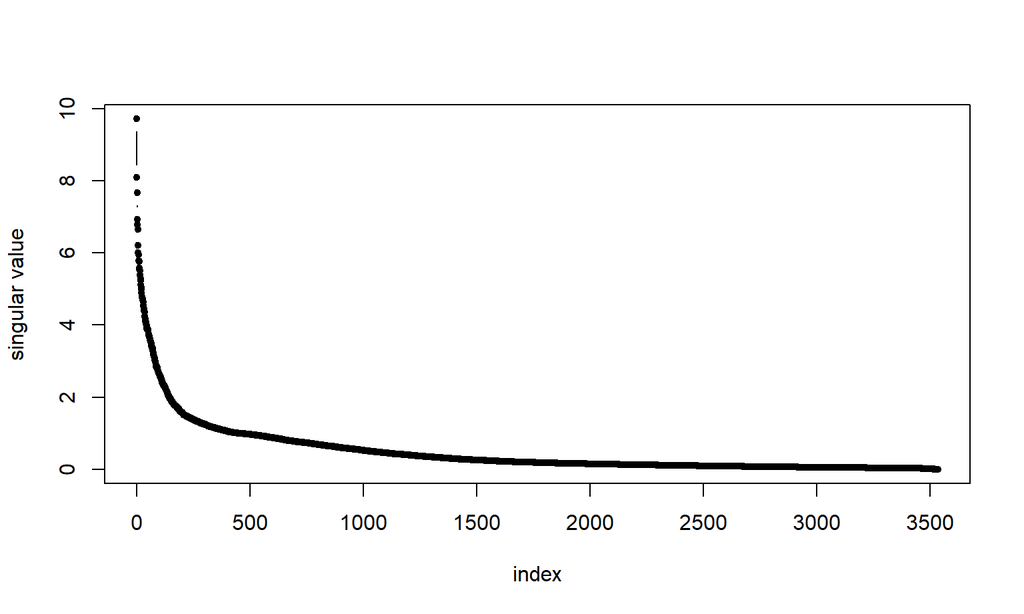

```r
eig_XtX <- eigen(XtX, symmetric = TRUE)

# eigen() returns values in decreasing order for symmetric matrices (usually).
lambda <- pmax(eig_XtX$values, 0)
s <- sqrt(lambda)

plot(s, type = "b", pch = 20, xlab = "index", ylab = "singular value")
```

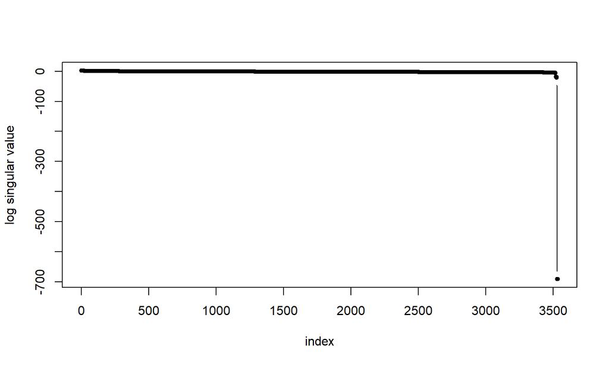

```r
plot(log(s + 1e-300), type = "b", pch = 20, xlab = "index", ylab = "log singular value")
```

```r
V <- eig_XtX$vectors
Xty <- crossprod(Xmat, y) # t(X) y

# safe division: avoid dividing by 0 exactly
eps <- .Machine$double.eps
inv_lambda <- ifelse(lambda > eps, 1 / lambda, 0)

beta_svd <- V %*% (inv_lambda * (t(V) %*% Xty))
beta_svd <- as.numeric(beta_svd)

summary(beta_svd)
```

```
##    Min. 1st Qu.  Median    Mean 3rd Qu.    Max.
## -428.33   15.84   34.03   32.75   50.99  560.06
```

```r
yhat_svd <- as.numeric(Xmat %*% beta_svd)
rmse_svd <- sqrt(mean((y - yhat_svd)^2))
cat("RMSE (svd pseudo-inverse) =", rmse_svd, "\n")
```

```
## RMSE (svd pseudo-inverse) = 2.48633
```

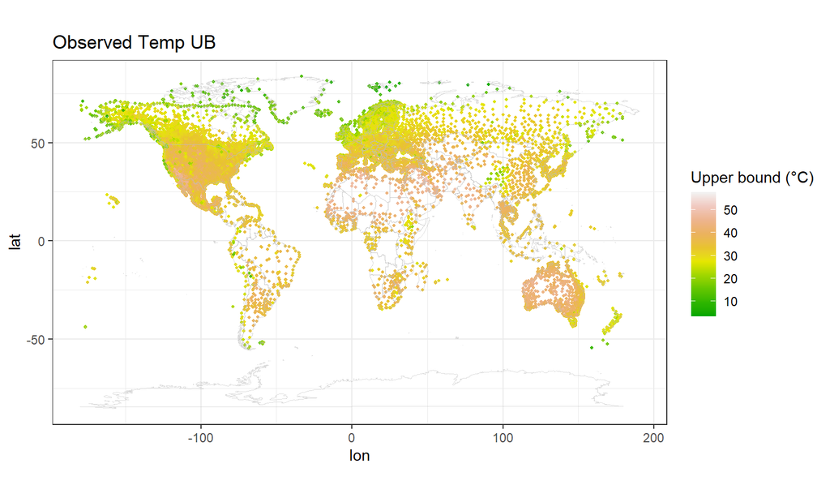

```r
stations$y_obs <- y
stations$yhat_svd <- yhat_svd

p_obs <- ggplot(stations) +
  geom_point(aes(lon, lat, col = y_obs), size = 0.7) +
  geom_path(data = map_data("world"),
            aes(long, lat, group = group),
            color="gray", linewidth=0.2, alpha=0.5) +
  scale_color_gradientn(colours = terrain.colors(10), name = "Upper bound (°C)") +
  coord_fixed(1.3) + theme_bw() + labs(x="lon", y="lat", title="Observed Temp UB")

p_rec <- ggplot(stations) +
  geom_point(aes(lon, lat, col = yhat_svd), size = 0.7) +
  geom_path(data = map_data("world"),
            aes(long, lat, group = group),
            color="gray", linewidth=0.2, alpha=0.5) +
  scale_color_gradientn(colours = terrain.colors(10), name = "Temp basis representation") +
  coord_fixed(1.3) + theme_bw() + labs(x="lon", y="lat", title="Reconstruction X beta_hat_svd")

p_obs
```

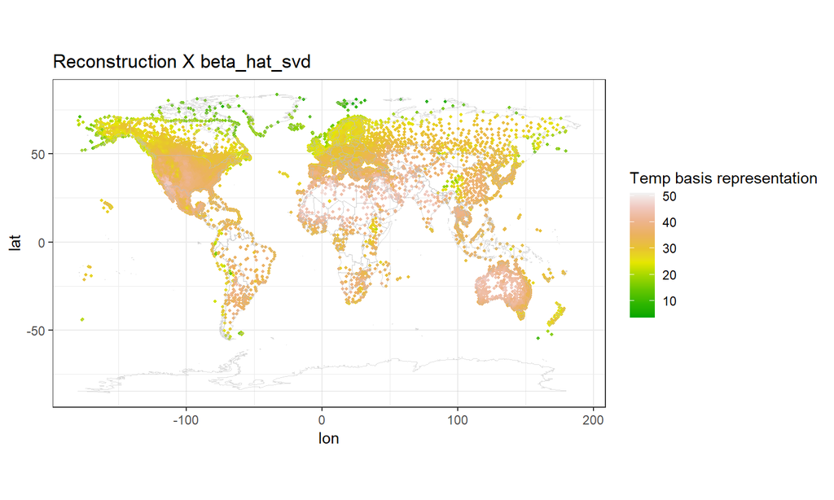

```r
p_rec
```

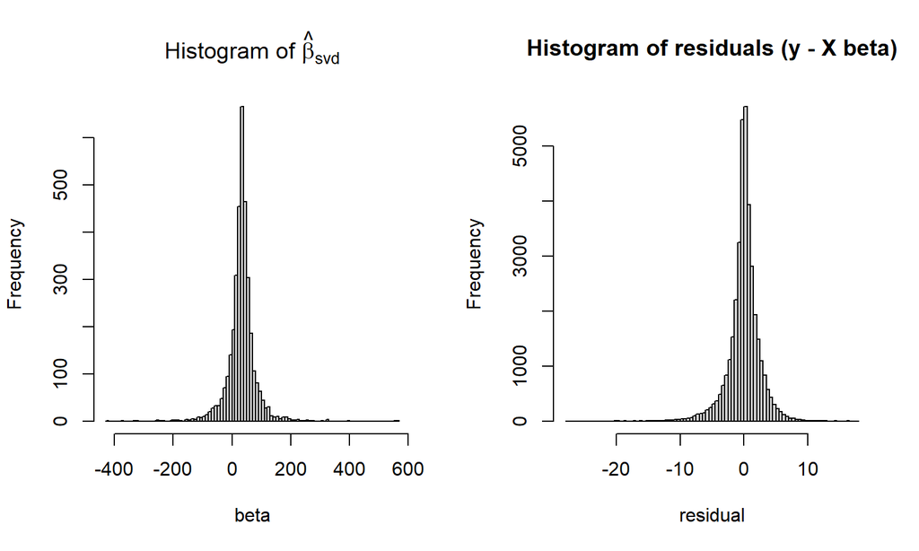

```r
resid_svd <- y - yhat_svd

par(mfrow = c(1,2))
hist(beta_svd, breaks = 80, main = expression("Histogram of " * hat(beta)[svd]), xlab = "beta")
hist(resid_svd, breaks = 80, main = "Histogram of residuals (y - X beta)", xlab = "residual")
```

```r
par(mfrow = c(1,1))



# ---- Choose tau based on elbow (1% of largest singular value)
tau <- 0.01 * max(s)
cat("Using tau =", tau, "\n")
```

```
## Using tau = 0.09722741
```

```r
keep <- s >= tau
inv_lambda_trunc <- ifelse(keep, 1 / lambda, 0)

beta_tau <- V %*% (inv_lambda_trunc * (t(V) %*% Xty))
beta_tau <- as.numeric(beta_tau)

summary(beta_tau)
```

```
##    Min. 1st Qu.  Median    Mean 3rd Qu.    Max.
## -171.73   24.03   33.33   32.75   41.96  243.87
```

```r
yhat_tau <- as.numeric(Xmat %*% beta_tau)
rmse_tau <- sqrt(mean((y - yhat_tau)^2))
cat("RMSE (truncated SVD) =", rmse_tau, "\n")
```

```
## RMSE (truncated SVD) = 2.537495
```

```r
cat("Max |beta_svd| =", max(abs(beta_svd)), "\n")
```

```
## Max |beta_svd| = 560.0647
```

```r
cat("Max |beta_tau| =", max(abs(beta_tau)), "\n")
```

```
## Max |beta_tau| = 243.8717
```

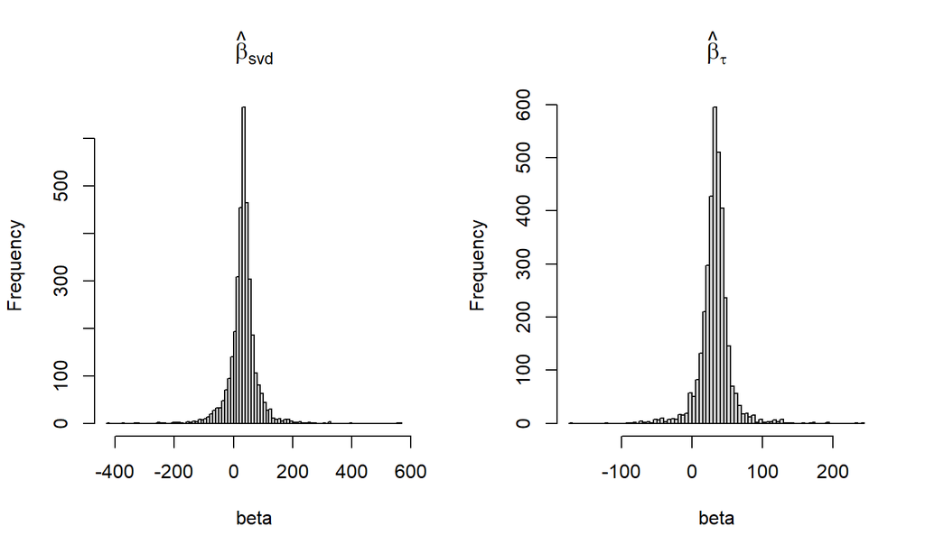

```r
par(mfrow = c(1,2))
hist(beta_svd, breaks = 80, main = expression(hat(beta)[svd]), xlab = "beta")
hist(beta_tau, breaks = 80, main = expression(hat(beta)[tau]), xlab = "beta")
```

```r
par(mfrow = c(1,1))



yhat_tau <- as.numeric(Xmat %*% beta_tau)
rmse_tau <- sqrt(mean((y - yhat_tau)^2))
cat("RMSE (truncated) =", rmse_tau, "\n")
```

```
## RMSE (truncated) = 2.537495
```

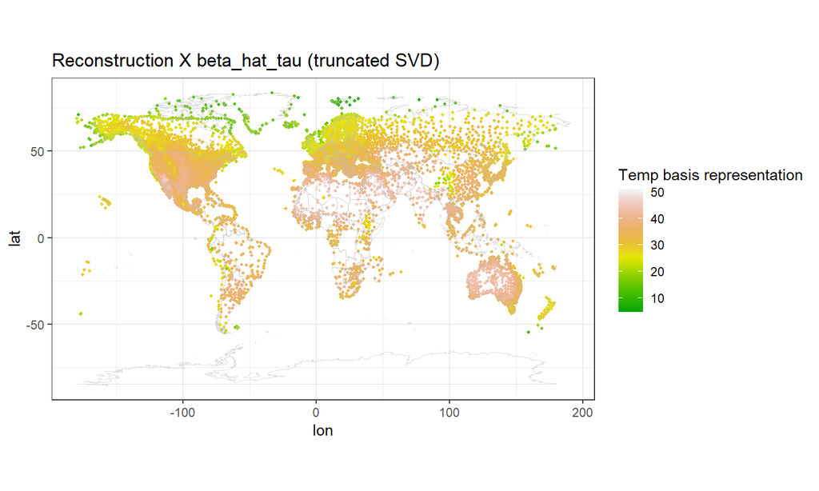

```r
stations$yhat_tau <- yhat_tau

p_rec_tau <- ggplot(stations) +
  geom_point(aes(lon, lat, col = yhat_tau), size = 0.7) +
  geom_path(data = map_data("world"),
            aes(long, lat, group = group),
            color="gray", linewidth=0.2, alpha=0.5) +
  scale_color_gradientn(colours = terrain.colors(10), name = "Temp basis representation") +
  coord_fixed(1.3) + theme_bw() + labs(x="lon", y="lat", title="Reconstruction X beta_hat_tau (truncated SVD)")

p_rec_tau
```

```r
ridge_beta <- function(lambda_ridge) {
  w <- 1 / (lambda + lambda_ridge)   # lambda here = eigenvalues of XtX
  b <- V %*% (w * (t(V) %*% Xty))
  as.numeric(b)
}

lams <- c(1e-6, 1e-4, 1e-2, 1, 10)
out <- data.frame(lambda = lams, RMSE = NA_real_, maxAbsBeta = NA_real_)

for (i in seq_along(lams)) {
  b <- ridge_beta(lams[i])
  yhat <- as.numeric(Xmat %*% b)
  out$RMSE[i] <- sqrt(mean((y - yhat)^2))
  out$maxAbsBeta[i] <- max(abs(b))
}
out
```

| lambda | RMSE | maxAbsBeta |
| --- | --- | --- |
| 1e-06 | 2.486330 | 553.97625 |
| 1e-04 | 2.486791 | 439.63638 |
| 1e-02 | 2.531388 | 158.25158 |
| 1e+00 | 5.073671 | 55.03081 |
| 1e+01 | 12.805850 | 37.86015 |

## Problem 2

We are given a global dataset with temperature upper bounds evaluated at weather stations. Let
$$y \in \mathbb{R}^n,\qquad X \in \mathbb{R}^{n\times p},$$
where $y$ is the vector `Temp_UB` (upper bounds in $^\circ$C), and $X$ is the design matrix `Xmat` whose columns are localized spatial basis functions. In our data,
$$n = 37511,\qquad p = 3535.$$

### (1) Visualizing two basis functions

I visualized two additional basis functions (e.g., Basis #100 and Basis #2000; see Figure P2-basis100 and Figure P2-basis2000). In both cases, the basis values are non-negligible only in a compact geographic neighborhood and are close to zero elsewhere. This confirms that each column of $X$ represents a spatially local “bump”.

### (2) What does “local basis function” mean?

A local basis function here is a spatially localized bump defined on station locations: it is large only near one region and nearly zero elsewhere. Figure 1 in the assignment (and my two additional plots) shows this locality clearly: each basis highlights a small geographic area rather than a global pattern. By combining many such local bumps through $X\beta$, we can represent complex spatial variation by adding up local contributions.

### (3a) Why does $\left(X^\top X\right)^{-1}$ fail?

The ordinary least-squares projection onto $\mathcal{S}=\mathrm{span}(X)$ is
$$\hat{y} = X\hat{\beta},\qquad \hat{\beta} = \left(X^\top
X\right)^{-1}X^\top y.$$
However, computing $\left(X^\top X\right)^{-1}$ using `solve(t(X)%*%X)` fails with a Lapack error indicating the system is exactly singular. In this context, “singular” means that $X^\top X$ is not invertible because $X$ does not have full column rank: there exist nontrivial linear dependencies among the columns of $X$, implying at least one eigenvalue of $X^\top X$ is zero (or numerically indistinguishable from zero). Consequently, the inverse does not exist (or is extremely unstable), and the classical formula for $\hat{\beta}$ breaks down.

### (4) SVD pseudoinverse solution and reconstruction

Using SVD, the Moore–Penrose pseudoinverse is
$$X^+ = V D^+ U^\top,\qquad D^+ =
\mathrm{diag}\left(\frac{1}{\sigma_i}\right),$$
(where $\frac{1}{\sigma_i}$ is treated as $0$ when $\sigma_i=0$). The SVD-based coefficient estimate is
$$\hat{\beta}_{\mathrm{svd}} = X^+y = V D^+ U^\top y.$$
The reconstruction is then
$$\hat{y}_{\mathrm{svd}} = X\hat{\beta}_{\mathrm{svd}},$$
and in our output the RMSE is approximately
$$\mathrm{RMSE} = \sqrt{\frac{1}{n}\sum_{i=1}^n
\left(y_i-\hat{y}_{\mathrm{svd},i}\right)^2}\approx 2.49.$$
Visually (Figure P2-obs vs Figure P2-recon-svd), the reconstructed field closely matches the large-scale spatial structure of the observed temperature upper bound field, while appearing slightly smoother in some regions. This smoothing is expected because the projection onto $\mathrm{span}(X)$ can suppress small-scale noise in the observational record.

### (4c) Why can $\hat{\beta}$ have outliers while $X\hat{\beta}$ looks reasonable?

Large or outlying coefficients can occur because the inverse problem is ill-conditioned: components aligned with tiny singular values are weakly identifiable, and the pseudoinverse inflates them via $1/\sigma_i$. Importantly, many of these inflated directions correspond to near-null directions of $X$, so they can change $\hat{\beta}$ substantially while having limited impact on the reconstructed field $X\hat{\beta}$. Thus, it is possible for $X\hat{\beta}_{\mathrm{svd}}$ to look visually reasonable even when $\hat{\beta}_{\mathrm{svd}}$ contains extreme values.

### (5) Truncated SVD

To stabilize the pseudoinverse solution, we modify the inversion of small singular values.

Recall that using the spectral decomposition
$$X^\top X = V \Lambda V^\top,$$
the pseudoinverse estimator can be written as
$$\hat{\beta}_{\mathrm{svd}}
=
V \Lambda^+ V^\top X^\top y,$$
where
$$\Lambda^+_{ii} =
\begin{cases}
\frac{1}{\lambda_i}, & \lambda_i > 0, \\
0, & \lambda_i = 0.
\end{cases}$$

When some eigenvalues $\lambda_i$ are very small, the terms
$$\frac{1}{\lambda_i}$$
become extremely large, leading to unstable and inflated coefficients.

In truncated SVD, we introduce a threshold $\tau$ and define
$$\Lambda^+_{\tau,ii} =
\begin{cases}
\frac{1}{\lambda_i}, & \lambda_i \ge \tau^2, \\
0, & \lambda_i < \tau^2.
\end{cases}$$

Equivalently, using singular values $\sigma_i = \sqrt{\lambda_i}$, we remove directions where
$$\sigma_i < \tau.$$

Based on the elbow observed in the singular value decay plot, we choose
$$\tau = 0.01 \times \max(\sigma_i).$$

This removes weakly identifiable directions associated with near-zero singular values.

Empirically, the reconstruction error
$$\mathrm{RMSE}_\tau
=
\sqrt{
\frac{1}{n}
\sum_{i=1}^{n}
\left(y_i - \hat{y}_{\tau,i}\right)^2
}$$
remains very close to the SVD solution, indicating that predictive accuracy is largely preserved.

However, the distribution of coefficients changes substantially.  
Compared to $\hat{\beta}_{\mathrm{svd}}$, the truncated estimator $\hat{\beta}_\tau$ exhibits noticeably smaller magnitude and reduced heavy tails in its histogram.

At the same time, the reconstructed temperature field retains the main large-scale spatial structure.

Therefore, truncated SVD improves numerical stability and coefficient regularity without materially degrading the reconstruction.

### (6) Ridge Regularization

Ridge regression solves the penalized least squares problem
$$\hat{\beta}_\lambda
=
\arg\min_\beta
\left\{
\|y - X\beta\|_2^2
+
\lambda \|\beta\|_2^2
\right\}.$$

Using the spectral decomposition of $X^\top X$, the solution can be written as
$$\hat{\beta}_\lambda
=
V
\mathrm{diag}
\!\left(
\frac{1}{\lambda_i + \lambda}
\right)
V^\top X^\top y.$$

The shrinkage factor
$$\frac{1}{\lambda_i + \lambda}$$
reduces the influence of directions corresponding to small eigenvalues, thereby stabilizing the inverse problem.

These results illustrate the classical bias–variance tradeoff: increasing $\lambda$ improves numerical stability, but excessive regularization sacrifices predictive accuracy.

## Problem 3

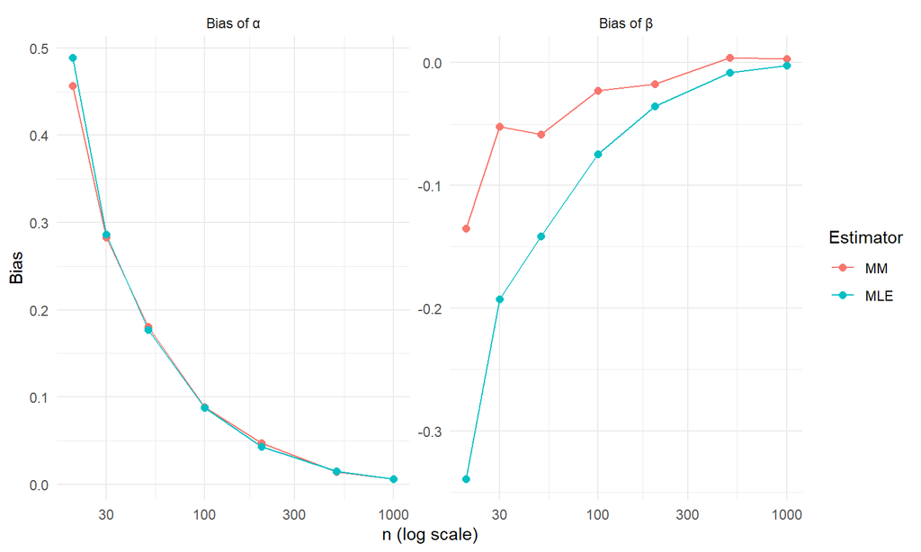

```r
#clear everything in memory
rm(list=ls(all=TRUE));
options(max.print=999999)

#Set working directory
setwd("C:/Users/18835/iCloudDrive/9250")

#Problem 3
#Simple simulation study

set.seed(123)

alpha0 <- 3
beta0  <- 7

n_grid <- c(20, 30, 50, 100, 200, 500, 1000)
R <- 5000  # Monte Carlo replications (adjust if needed)

#MM estimator
mm_gamma <- function(x) {
  m <- mean(x)
  s2 <- var(x)
  alpha_hat <- m^2 / s2
  beta_hat  <- s2 / m
  c(alpha = alpha_hat, beta = beta_hat)
}

#MLE estimator
mle_gamma <- function(x) {
  m <- mean(x)
  meanlog <- mean(log(x))
  rhs <- log(m) - meanlog

  #Function whose root gives alpha: log(a) - digamma(a) - rhs = 0
  f <- function(a) log(a) - digamma(a) - rhs

  #Using MM as rough initial scale for bracketing
  mm <- mm_gamma(x)
  a0 <- mm["alpha"]

  #Robust bracketing for uniroot
  lower <- max(1e-6, a0 / 10)
  upper <- a0 * 10 + 10

    #A few expansions
  for (k in 1:10) {
    if (is.finite(f(lower)) && is.finite(f(upper)) && f(lower) * f(upper) < 0) break
    upper <- upper * 2
  }

  #If not bracketed, back to a generic wide bracket
  if (!(is.finite(f(lower)) && is.finite(f(upper)) && f(lower) * f(upper) < 0)) {
    lower <- 1e-6
    upper <- 1e4
  }

  alpha_hat <- uniroot(f, lower = lower, upper = upper, tol = 1e-10)$root
  beta_hat  <- m / alpha_hat

  c(alpha = alpha_hat, beta = beta_hat)
}

#simulation for one n
simulate_one_n <- function(n, R, alpha0, beta0) {
  out <- matrix(NA_real_, nrow = R, ncol = 4)
  colnames(out) <- c("alpha_mm", "beta_mm", "alpha_mle", "beta_mle")

  for (r in 1:R) {
    x <- rgamma(n, shape = alpha0, scale = beta0)

    mm <- mm_gamma(x)
    mle <- mle_gamma(x)

    out[r, ] <- c(mm["alpha"], mm["beta"], mle["alpha"], mle["beta"])
  }
  out
}

#Computing bias and MSE
summarize_bias_mse <- function(estimates, true_alpha, true_beta) {
  alpha_mm <- estimates[, "alpha_mm"]
  beta_mm  <- estimates[, "beta_mm"]
  alpha_mle <- estimates[, "alpha_mle"]
  beta_mle  <- estimates[, "beta_mle"]

  data.frame(
    method = rep(c("MM","MLE"), each = 2),
    param  = rep(c("alpha","beta"), times = 2),
    bias   = c(mean(alpha_mm) - true_alpha,
               mean(beta_mm)  - true_beta,
               mean(alpha_mle) - true_alpha,
               mean(beta_mle)  - true_beta),
    mse    = c(mean((alpha_mm - true_alpha)^2),
               mean((beta_mm  - true_beta)^2),
               mean((alpha_mle - true_alpha)^2),
               mean((beta_mle  - true_beta)^2))
  )
}


#looping over n
results_list <- vector("list", length(n_grid))

for (i in seq_along(n_grid)) {
  n <- n_grid[i]
  est <- simulate_one_n(n, R, alpha0, beta0)
  summ <- summarize_bias_mse(est, alpha0, beta0)
  summ$n <- n
  results_list[[i]] <- summ
}

results <- do.call(rbind, results_list)

#Plotting bias and MSE using ggplot
library(ggplot2)

results$method <- factor(results$method, levels = c("MM", "MLE"))
results$param  <- factor(results$param,  levels = c("alpha", "beta"))

#Bias plots
p_bias <- ggplot(results, aes(x = n, y = bias, color = method)) +
  geom_line() +
  geom_point(size = 2) +
  scale_x_log10() +
  facet_wrap(~ param, scales = "free_y", ncol = 2,
             labeller = as_labeller(c(alpha = "Bias of α", beta = "Bias of β"))) +
  labs(x = "n (log scale)", y = "Bias", color = "Estimator") +
  theme_minimal()

p_bias
```

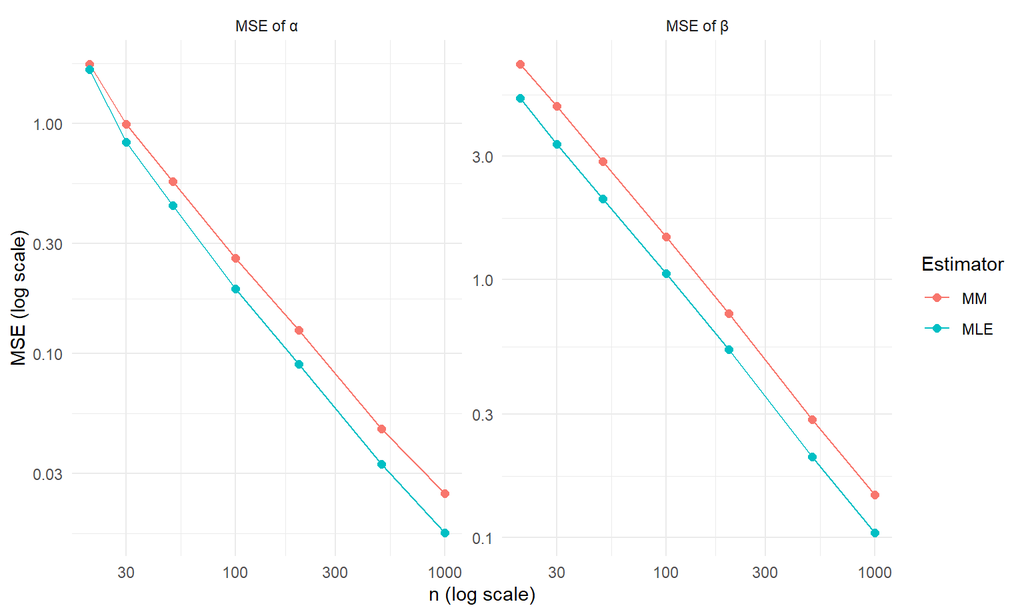

```r
#MSE plots
p_mse <- ggplot(results, aes(x = n, y = mse, color = method)) +
  geom_line() +
  geom_point(size = 2) +
  scale_x_log10() +
  scale_y_log10() +
  facet_wrap(~ param, scales = "free_y", ncol = 2,
             labeller = as_labeller(c(alpha = "MSE of α", beta = "MSE of β"))) +
  labs(x = "n (log scale)", y = "MSE (log scale)", color = "Estimator") +
  theme_minimal()

p_mse
```

## Problem 4

```r
#clear everything in memory
rm(list=ls(all=TRUE));
options(max.print=999999)

#Set working directory
setwd("C:/Users/18835/iCloudDrive/9250")

#Problem 4
#Monte Carlo methods for random matrices

#Prob 4.1

library(ggplot2)

set.seed(1)

mc_trace <- function(m, N) {
    tr_vals <- replicate(N, {
    R <- matrix(rnorm(m*m), m, m)
    sum(R^2)
  })
  mu_hat <- mean(tr_vals)
  mcse   <- sd(tr_vals) / sqrt(N)
  list(values = tr_vals, mean = mu_hat, mcse = mcse)
}

N_trace_100  <- 2000
N_trace_1000 <- 300   #smaller because m^2 draws per replicate

res_tr_100  <- mc_trace(m = 100,  N = N_trace_100)
res_tr_1000 <- mc_trace(m = 1000, N = N_trace_1000)

cat("Part (1): E[tr(Sigma)] = m^2 analytically.\n")
```

```
## Part (1): E[tr(Sigma)] = m^2 analytically.
```

```r
cat("m=100  : theory=", 100^2,  " MC mean=", res_tr_100$mean,
    " MCSE=", res_tr_100$mcse, "\n")
```

```
## m=100  : theory= 10000  MC mean= 10002.65  MCSE= 3.127569
```

```r
cat("m=1000 : theory=", 1000^2, " MC mean=", res_tr_1000$mean,
    " MCSE=", res_tr_1000$mcse, "\n")
```

```
## m=1000 : theory= 1e+06  MC mean= 1000032  MCSE= 84.04165
```

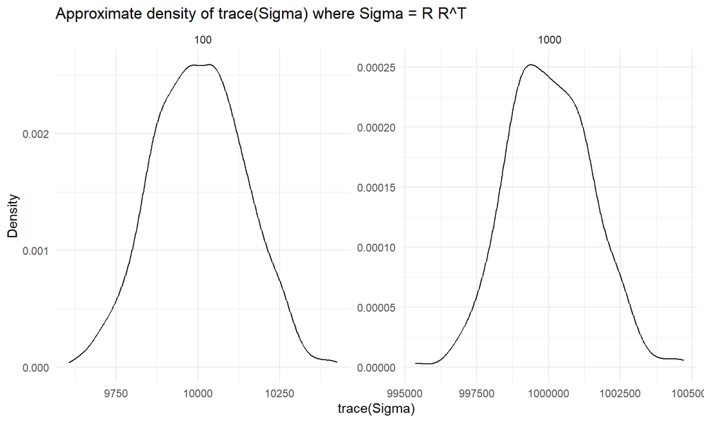

```r
df_tr <- rbind(
  data.frame(m = "100",  tr = res_tr_100$values),
  data.frame(m = "1000", tr = res_tr_1000$values)
)

ggplot(df_tr, aes(x = tr)) +
  geom_density() +
  facet_wrap(~ m, scales = "free") +
  labs(title = "Approximate density of trace(Sigma) where Sigma = R R^T",
       x = "trace(Sigma)", y = "Density") +
  theme_minimal()
```

```r
#Prob 4.2

power_lambda1 <- function(R, n_iter = 30) {
  m <- nrow(R)
  v <- rnorm(m)
  v <- v / sqrt(sum(v^2))

  for (k in 1:n_iter) {
    w <- R %*% (t(R) %*% v)
    v <- w / sqrt(sum(w^2))
  }
  as.numeric(crossprod(t(R) %*% v))
}

mc_lambda1 <- function(m, N, n_iter = 30) {
  lam_vals <- replicate(N, {
    R <- matrix(rnorm(m*m), m, m)
    power_lambda1(R, n_iter = n_iter)
  })
  mu_hat <- mean(lam_vals)
  mcse   <- sd(lam_vals) / sqrt(N)
  list(values = lam_vals, mean = mu_hat, mcse = mcse)
}

set.seed(2)

N_lam_100  <- 500
N_lam_1000 <- 60

res_lam_100  <- mc_lambda1(m=100,  N=N_lam_100,  n_iter=40)
res_lam_1000 <- mc_lambda1(m=1000, N=N_lam_1000, n_iter=60)

cat("Part (2): Largest eigenvalue Monte Carlo summaries\n")
```

```
## Part (2): Largest eigenvalue Monte Carlo summaries
```

```r
cat("m=100  : MC mean=", res_lam_100$mean,  " MCSE=", res_lam_100$mcse,  "\n")
```

```
## m=100  : MC mean= 381.4989  MCSE= 0.6865858
```

```r
cat("m=1000 : MC mean=", res_lam_1000$mean, " MCSE=", res_lam_1000$mcse, "\n")
```

```
## m=1000 : MC mean= 3939.075  MCSE= 5.436893
```

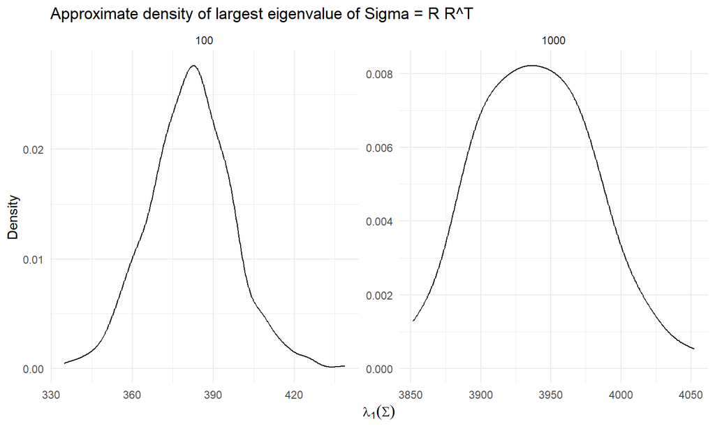

```r
df_lam <- rbind(
  data.frame(m="100",  lambda1 = res_lam_100$values),
  data.frame(m="1000", lambda1 = res_lam_1000$values)
)

ggplot(df_lam, aes(x = lambda1)) +
  geom_density() +
  facet_wrap(~ m, scales = "free") +
  labs(title = "Approximate density of largest eigenvalue of Sigma = R R^T",
       x = expression(lambda[1](Sigma)), y = "Density") +
  theme_minimal()
```

```r
#Prob 4.3

set.seed(3)

m_grid <- c(20, 50, 100, 200, 400, 600, 800, 1000)

# sample sizes per m (increase for small m, decrease for large m)
N_by_m <- ifelse(m_grid <= 100, 300,
                 ifelse(m_grid <= 400, 120, 50))

iters_by_m <- ifelse(m_grid <= 100, 40,
                     ifelse(m_grid <= 400, 50, 60))

summ <- lapply(seq_along(m_grid), function(i) {
  m <- m_grid[i]
  N <- N_by_m[i]
  it <- iters_by_m[i]
  res <- mc_lambda1(m = m, N = N, n_iter = it)
  data.frame(m = m, N = N, n_iter = it, Ehat = res$mean, MCSE = res$mcse)
})

df_E <- do.call(rbind, summ)

print(df_E)
```

```
##      m   N n_iter       Ehat      MCSE
## 1   20 300     40   70.54966 0.4742466
## 2   50 300     40  187.71834 0.6479141
## 3  100 300     40  381.24977 0.9316208
## 4  200 120     50  774.85624 2.0555178
## 5  400 120     50 1560.91966 2.6480611
## 6  600  50     60 2356.53874 3.9461229
## 7  800  50     60 3147.45022 5.3700531
## 8 1000  50     60 3927.31383 6.2024192
```

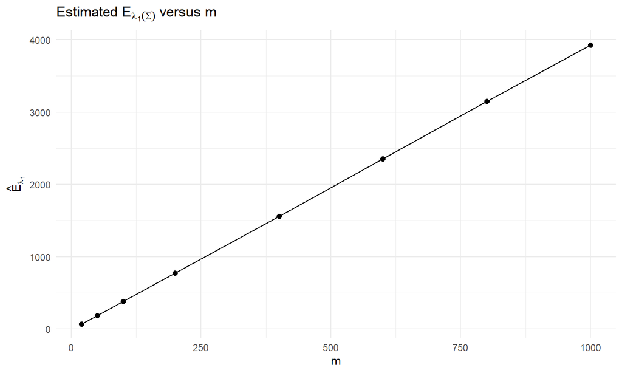

```r
ggplot(df_E, aes(x = m, y = Ehat)) +
  geom_line() +
  geom_point(size = 2) +
  geom_errorbar(aes(ymin = Ehat - 1.96*MCSE, ymax = Ehat + 1.96*MCSE),
                width = 0) +
  labs(title = expression(paste("Estimated ", E[lambda[1](Sigma)], " versus m")),
       x = "m", y = expression(hat(E)[lambda[1]])) +
  theme_minimal()
```

## Problem 5

```r
#clear everything in memory
rm(list=ls(all=TRUE));
options(max.print=999999)

#Set working directory
setwd("C:/Users/18835/iCloudDrive/9250")

#Problem 5

#Code optimization & parallel computing

#lookup table once
lut <- -cos(2 * (0:255))

myfunc_opt <- function(v_s, i_v, iter) {
  # d_val depends only on i
  d_val <- as.integer(round(i_v %% 256))
  trig  <- lut[d_val + 1L]
  scale <- trig / cos(iter)
  v_s * scale
}


N1 <- 1e3; N2 <- 2e3; N_tot <- 64
vi_v <- rep(NA, N1)
vd_s <- matrix(NA, N1, N2)

d_val <- as.integer(round(vi_v %% 256))
trig  <- lut[d_val + 1L]
rs    <- rowSums(vd_s)
denom <- nrow(vd_s) * ncol(vd_s)


#mean(res_mat) without res_mat
Res_fast <- numeric(N_tot)

ptm <- proc.time()
for (iter in 1:N_tot) {
  Res_fast[iter] <- sum(rs * trig) / (denom * cos(iter))
}
proc.time() - ptm
```

```
##    user  system elapsed
##    0.00    0.00    0.02
```